# Brownlows Bets

Karen Hernandez

September 9, 2020

# 1 Introduction

At the first day of class there are 35 students in Math Statistics class and professor Brownlow always proposes this bet to his students "I will wager $2 to your bet of $1 that at least two people in today’s class have the same birthday. He tells me he has made that bet 637 times so far. Where do you think his profits are? Discuss this in a markdown document

# 2 Methods what are the fair odds?

Simulate the betting process 1000 times. Will characterize the results on the simulation. A re sampling approach will be utilized in order to estimate what Professor Brownslow profits are. A 95% confidence interval will be used to find the approximate range of Brownslows profits.

# 3 Profit Estimate

```r
days=1:365
saveProfit=vector("numeric")
for(run in 1:1000) {

profit=0
for(i in 1:637){
  bdays=sample(days,size=35,replace=TRUE)
  n=length(unique(bdays))
  if(n<35) {
    profit=profit+1
  } else{profit=profit-2}
}
saveProfit[run]=profit
}
```

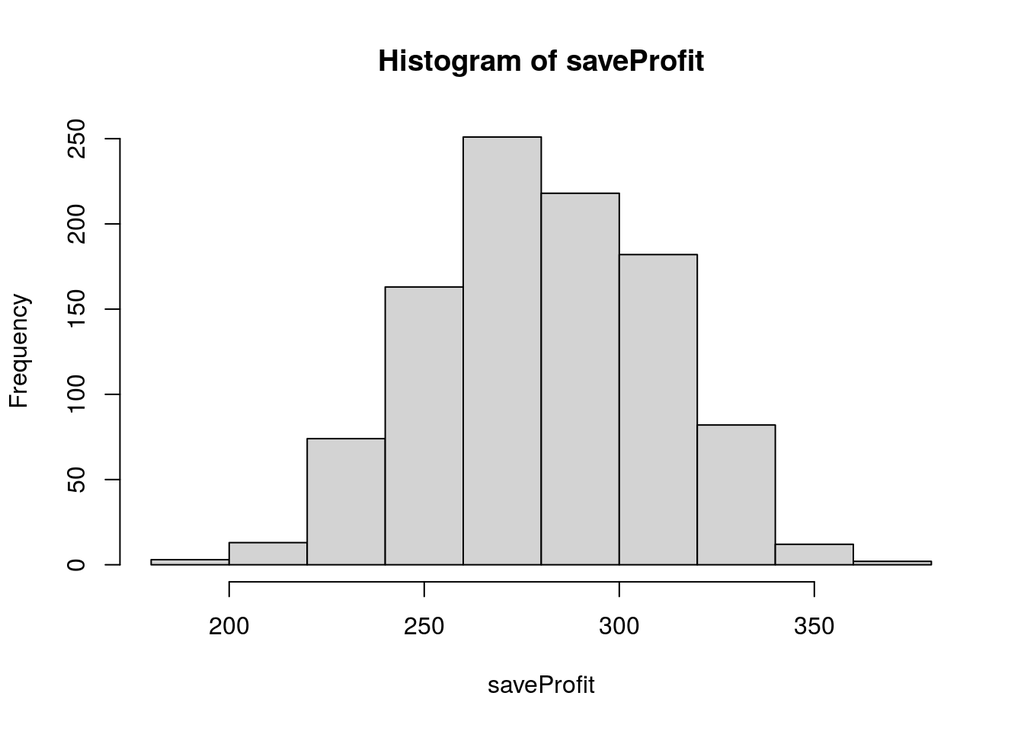

```r
hist(saveProfit)
```

```r
print(mean(saveProfit))
```

```
## [1] 281.146
```

# 4 Confidence Interval

```r
sortProfit=sort(saveProfit)
print(sortProfit[25])
```

```
## [1] 226
```

```r
print(sortProfit[975])
```

```
## [1] 337
```

The 95% confidence interval shows that the value range from 226 to 337. However if you run that code again, the values will continue to change.

We know now that 35 students is the wrong size for this 2:1 bet.